# Project 5 - Group 1

### Import Data

```python
import pandas as pd
```

```python
#reading data
data = pd.read_csv('bank-marketing.csv')
data.head(3)
```

|  | age | job | marital | education | default | housing | loan | contact | month | day_of_week | ... | campaign | pdays | previous | poutcome | emp.var.rate | cons.price.idx | cons.conf.idx | euribor3m | nr.employed | y |
| --- | --- | --- | --- | --- | --- | --- | --- | --- | --- | --- | --- | --- | --- | --- | --- | --- | --- | --- | --- | --- | --- |
| 0 | 56 | housemaid | married | basic.4y | no | no | no | telephone | may | mon | ... | 1 | 999 | 0 | nonexistent | 1.1 | 93.994 | -36.4 | 4.857 | 5191.0 | no |
| 1 | 57 | services | married | high.school | unknown | no | no | telephone | may | mon | ... | 1 | 999 | 0 | nonexistent | 1.1 | 93.994 | -36.4 | 4.857 | 5191.0 | no |
| 2 | 37 | services | married | high.school | no | yes | no | telephone | may | mon | ... | 1 | 999 | 0 | nonexistent | 1.1 | 93.994 | -36.4 | 4.857 | 5191.0 | no |

3 rows × 21 columns

### Select Features and Target Column

From the Project 3, we have 4 common features resulted from 3 methods which are Univariate, RFE, Feature Importance:

- **duration**: last contact duration, in seconds (numeric)
- **euribor3m**: euribor 3 month rate - daily indicator (numeric)
- **emp.var.rate**: employment variation rate - quarterly indicator (numeric)
- **campaign**: number of contacts performed during this campaign and for this client (numeric, includes last contact)

We're also interested in these features resulted independently from 3 methods of feature selections above:

- **age**: (numeric)
- **cons.price.idx**: consumer price index - monthly indicator (numeric)

The target variable:

- **y**: has the client subscribed a term deposit? (binary: 'yes','no')

```python
# Define features and target variable
X = data[['duration', 'euribor3m', 'emp.var.rate', 'campaign', 'age', 'cons.price.idx']]
y = data['y']

# Turn the target data from categorical to numerical data
y = y.map({'no': 0, 'yes': 1})
y.value_counts()
```

```
0    36548
1     4640
Name: y, dtype: int64
```

### Build a Decision Tree

```python
from sklearn.tree import DecisionTreeClassifier, plot_tree
import pandas as pd
import matplotlib.pyplot as plt
```

```python
# Initialize Decision Tree Classifier
clf = DecisionTreeClassifier(max_depth=5, min_samples_split=10, min_samples_leaf=5, max_features='auto')

# Train the model
clf.fit(X, y)
```

```
DecisionTreeClassifier(max_depth=5, max_features='auto', min_samples_leaf=5,
                       min_samples_split=10)
```

### Plot the Decision Tree

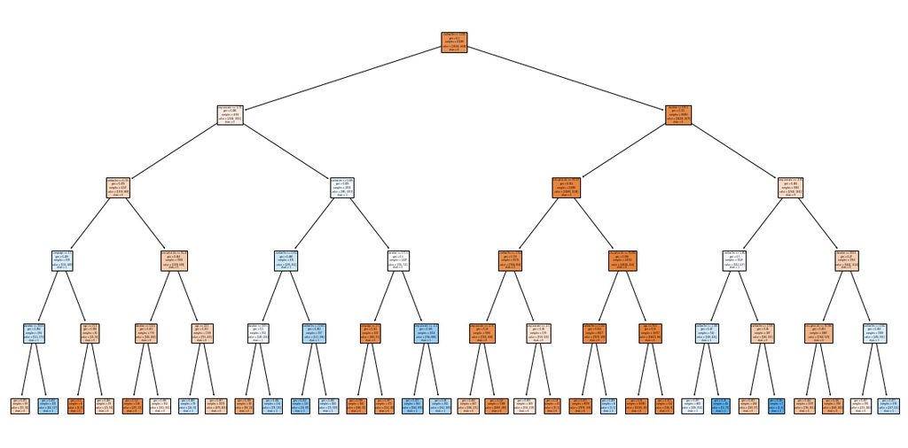

```python
# Visualize the decision tree
plt.figure(figsize=(20,10))
plot_tree(clf, feature_names=X.columns, class_names=[str(c) for c in sorted(y.unique())], filled=True)
plt.show()
```

### Decisions based on Decision Tree

```python
# Get the feature importance
importances = clf.feature_importances_
```

```python
# Create a DataFrame to display the feature importance
feature_importance_df = pd.DataFrame({
    'Feature': X.columns,
    'Importance': importances
})
```

```python
# Sort the DataFrame by importance in descending order
feature_importance_df = feature_importance_df.sort_values('Importance', ascending=False)
```

```python
# Print the features at the top of the decision tree
print(feature_importance_df.head())
```

```
          Feature  Importance
0        duration    0.477711
1       euribor3m    0.427073
2    emp.var.rate    0.051864
5  cons.price.idx    0.039313
4             age    0.002472
```

**Observation**

- Based on the dataframe of feature importance of Decision Tree, we can see the "duration" is the most important feature which is placed at the top of the Decision Tree.
- Following that, "emp.var.rate" and "euribor3m" are the next importance features placed at the 2nd top of the Decision Tree.

**Decisions**

- The Decision Tree suggests that "duration" feature is the most importance feature affecting to whether a customer wants to subscribe a term deposit or not. Thus, a marketer can consider a marketing campaign focusing on customers having longer last contact duration.
- "euribor3m" - an economic indicator, and "emp.var.rate" - employment variation rate are important features in the Decision Tree. It suggests that the macroeconomic situations (about economy and employment situation) affects significantly on customer decision to subscribe a term deposit. A marketer should focus closely on the economy changes and build a marketing campaign suitable with each economic situation to attract customers.
- "cons.price.idx" - consumer price index - a feature measures the economic inflation which affects to the spending decision of customers. It suggests that a marketer should notice this CPI feature to make some adjustment on promotion campaign that can attract customers during a high CPI time period.